# Final Report

### 4. Employment and economic indicators

`Longley` dataset presents 7 variables from 1947 to 1962 that can be used for predicting the number of employed persons in the USA.

• Year

• Population - Non-institutionalized above 14-year-old population

• Unemployed - Number of unemployed

• GNP – Gross National Product

• GNP.deflator – Price deflator centered on year 1954

• Armed.Forces – Number of people in armed forces

A multiple regression model is fitted to this data

**4.1 Multiple regression analysis**

```r
summary(longley)
```

```
##   GNP.deflator         GNP          Unemployed     Armed.Forces
##  Min.   : 83.00   Min.   :234.3   Min.   :187.0   Min.   :145.6
##  1st Qu.: 94.53   1st Qu.:317.9   1st Qu.:234.8   1st Qu.:229.8
##  Median :100.60   Median :381.4   Median :314.4   Median :271.8
##  Mean   :101.68   Mean   :387.7   Mean   :319.3   Mean   :260.7
##  3rd Qu.:111.25   3rd Qu.:454.1   3rd Qu.:384.2   3rd Qu.:306.1
##  Max.   :116.90   Max.   :554.9   Max.   :480.6   Max.   :359.4
##    Population         Year         Employed
##  Min.   :107.6   Min.   :1947   Min.   :60.17
##  1st Qu.:111.8   1st Qu.:1951   1st Qu.:62.71
##  Median :116.8   Median :1954   Median :65.50
##  Mean   :117.4   Mean   :1954   Mean   :65.32
##  3rd Qu.:122.3   3rd Qu.:1958   3rd Qu.:68.29
##  Max.   :130.1   Max.   :1962   Max.   :70.55
```

```r
#Scaling the data
scl <- scale(longley)
scl_df <- data.frame(scl)
mlr <- lm(Employed~.,data= scl_df)
summary(mlr)
```

```
##
## Call:
## lm(formula = Employed ~ ., data = scl_df)
##
## Residuals:
##       Min        1Q    Median        3Q       Max
## -0.116776 -0.044896 -0.008019  0.028916  0.129669
##
## Coefficients:
##                Estimate Std. Error t value Pr(>|t|)
## (Intercept)  -1.752e-15  2.170e-02   0.000 1.000000
## GNP.deflator  4.628e-02  2.609e-01   0.177 0.863141
## GNP          -1.014e+00  9.479e-01  -1.070 0.312681
## Unemployed   -5.375e-01  1.300e-01  -4.136 0.002535 **
## Armed.Forces -2.047e-01  4.246e-02  -4.822 0.000944 ***
## Population   -1.012e-01  4.478e-01  -0.226 0.826212
## Year          2.480e+00  6.175e-01   4.016 0.003037 **
## ---
## Signif. codes:  0 '***' 0.001 '**' 0.01 '*' 0.05 '.' 0.1 ' ' 1
##
## Residual standard error: 0.0868 on 9 degrees of freedom
## Multiple R-squared:  0.9955, Adjusted R-squared:  0.9925
## F-statistic: 330.3 on 6 and 9 DF,  p-value: 4.984e-10
```

Multiple linear regression model is fitted to the data with R<sup>2</sup> > 99.5%.

**4.2 Multicolliniarity**

```r
library(car)
vif(mlr)
```

```
## GNP.deflator          GNP   Unemployed Armed.Forces   Population         Year
##    135.53244   1788.51348     33.61889      3.58893    399.15102    758.98060
```

```r
cor(scl_df)
```

```
##              GNP.deflator       GNP Unemployed Armed.Forces Population
## GNP.deflator    1.0000000 0.9915892  0.6206334    0.4647442  0.9791634
## GNP             0.9915892 1.0000000  0.6042609    0.4464368  0.9910901
## Unemployed      0.6206334 0.6042609  1.0000000   -0.1774206  0.6865515
## Armed.Forces    0.4647442 0.4464368 -0.1774206    1.0000000  0.3644163
## Population      0.9791634 0.9910901  0.6865515    0.3644163  1.0000000
## Year            0.9911492 0.9952735  0.6682566    0.4172451  0.9939528
## Employed        0.9708985 0.9835516  0.5024981    0.4573074  0.9603906
##                   Year  Employed
## GNP.deflator 0.9911492 0.9708985
## GNP          0.9952735 0.9835516
## Unemployed   0.6682566 0.5024981
## Armed.Forces 0.4172451 0.4573074
## Population   0.9939528 0.9603906
## Year         1.0000000 0.9713295
## Employed     0.9713295 1.0000000
```

Some variables should be removed to reduce the multicolliniarity.

**4.3 Step-wise method**

Stepwise method of multiple regression is used for selecting a model with reduced multicollinearity.

```r
library(MASS)
stp_mr <- stepAIC(mlr,direction = 'both')
```

```
## Start:  AIC=-73.42
## Employed ~ GNP.deflator + GNP + Unemployed + Armed.Forces + Population +
##     Year
##
##                Df Sum of Sq      RSS     AIC
## - GNP.deflator  1  0.000237 0.068052 -75.361
## - Population    1  0.000385 0.068200 -75.326
## - GNP           1  0.008619 0.076434 -73.503
## <none>                      0.067815 -73.417
## - Year          1  0.121520 0.189335 -58.989
## - Unemployed    1  0.128924 0.196739 -58.375
## - Armed.Forces  1  0.175200 0.243015 -54.996
##
## Step:  AIC=-75.36
## Employed ~ GNP + Unemployed + Armed.Forces + Population + Year
##
##                Df Sum of Sq      RSS     AIC
## - Population    1  0.001567 0.069619 -76.997
## <none>                      0.068052 -75.361
## - GNP           1  0.011867 0.079919 -74.789
## + GNP.deflator  1  0.000237 0.067815 -73.417
## - Year          1  0.123825 0.191877 -60.776
## - Unemployed    1  0.177550 0.245602 -56.826
## - Armed.Forces  1  0.194384 0.262436 -55.765
##
## Step:  AIC=-77
## Employed ~ GNP + Unemployed + Armed.Forces + Year
##
##                Df Sum of Sq     RSS     AIC
## <none>                      0.06962 -76.997
## + Population    1   0.00157 0.06805 -75.361
## + GNP.deflator  1   0.00142 0.06820 -75.326
## - GNP           1   0.03767 0.10729 -72.076
## - Year          1   0.15389 0.22351 -60.334
## - Armed.Forces  1   0.19301 0.26263 -57.754
## - Unemployed    1   0.32829 0.39791 -51.106
```

```r
summary(stp_mr)
```

```
##
## Call:
## lm(formula = Employed ~ GNP + Unemployed + Armed.Forces + Year,
##     data = scl_df)
##
## Residuals:
##       Min        1Q    Median        3Q       Max
## -0.120061 -0.035470 -0.006878  0.023829  0.128895
##
## Coefficients:
##                Estimate Std. Error t value Pr(>|t|)
## (Intercept)  -1.879e-15  1.989e-02   0.000 1.000000
## GNP          -1.137e+00  4.662e-01  -2.440 0.032833 *
## Unemployed   -5.557e-01  7.716e-02  -7.202 1.75e-05 ***
## Armed.Forces -2.011e-01  3.641e-02  -5.522 0.000180 ***
## Year          2.559e+00  5.189e-01   4.931 0.000449 ***
## ---
## Signif. codes:  0 '***' 0.001 '**' 0.01 '*' 0.05 '.' 0.1 ' ' 1
##
## Residual standard error: 0.07956 on 11 degrees of freedom
## Multiple R-squared:  0.9954, Adjusted R-squared:  0.9937
## F-statistic: 589.8 on 4 and 11 DF,  p-value: 9.5e-13
```

Best model is selected. Employment is best predicted by GNP, Unemployment, Armed Forces and Year.

**4.4 Principal Component Analysis**

Principal component analysis is used on the same data, to reduce dimensionality.

```r
rpca = prcomp(x=longley, scale=T)
summary(rpca)
```

```
## Importance of components:
##                           PC1    PC2     PC3     PC4     PC5     PC6     PC7
## Standard deviation     2.3522 1.0897 0.50221 0.12344 0.10313 0.03206 0.01608
## Proportion of Variance 0.7904 0.1696 0.03603 0.00218 0.00152 0.00015 0.00004
## Cumulative Proportion  0.7904 0.9601 0.99612 0.99830 0.99982 0.99996 1.00000
```

```r
rpca$x[,1]
```

```
##       1947       1948       1949       1950       1951       1952       1953
## -3.7619812 -3.2399564 -2.7621211 -2.4091075 -1.5410767 -1.0947545 -0.6539954
##       1954       1955       1956       1957       1958       1959       1960
## -0.1545799  0.1809465  0.7170900  1.2140437  1.7790878  2.1565376  2.6463217
##       1961       1962
##  3.2609692  3.6625764
```

```r
rpca$x[,2]
```

```
##       1947       1948       1949       1950       1951       1952       1953
##  0.6821378  0.7807091  1.5412760  1.2623474 -1.2529165 -1.9210578 -1.9303682
##       1954       1955       1956       1957       1958       1959       1960
## -0.5361761 -0.7014064 -0.5895881 -0.4535338  0.9344479  0.4014410  0.5117680
##       1961       1962
##  1.0515298  0.2193898
```

**Plot of first two components**

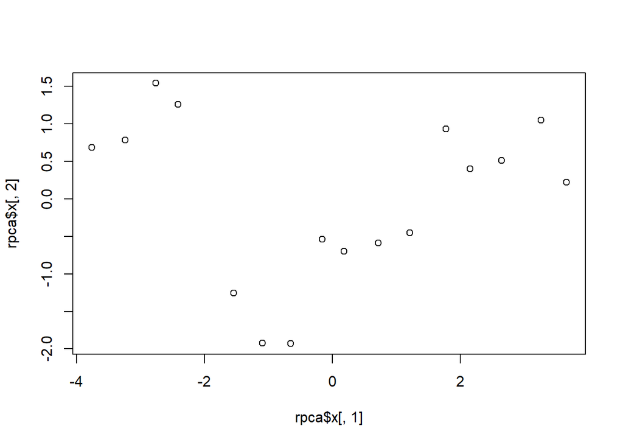

```r
plot(rpca$x[,1],rpca$x[,2])
```

Selection of the number of principal components

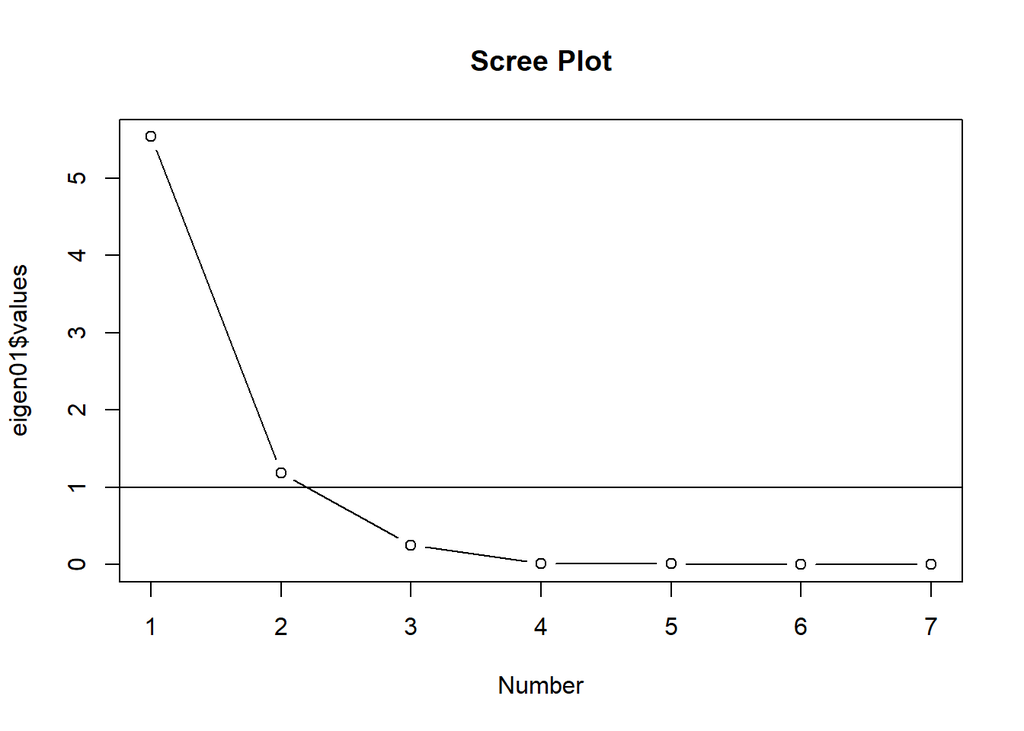

```r
cor01 <- cor(longley)
eigen01 <- eigen(cor01)
plot(eigen01$values, type = 'b', main = 'Scree Plot', xlab = 'Number')
abline(h=1, untf = FALSE)
```

Based on the elbow on scree plot and the Kaiser criterion, first two PCs are selected.

**4.5 Factor analysis**

```r
rfa <- factanal(x=longley, factors = 2, rotation = 'promax', scores = 'Bartlett')
rfa
```

```
##
## Call:
## factanal(x = longley, factors = 2, scores = "Bartlett", rotation = "promax")
##
## Uniquenesses:
## GNP.deflator          GNP   Unemployed Armed.Forces   Population         Year
##        0.016        0.005        0.005        0.483        0.008        0.005
##     Employed
##        0.017
##
## Loadings:
##              Factor1 Factor2
## GNP.deflator  0.992
## GNP           0.999
## Unemployed    0.612   0.788
## Armed.Forces  0.443  -0.566
## Population    0.991   0.103
## Year          0.996
## Employed      0.983  -0.124
##
##                Factor1 Factor2
## SS loadings      5.493   0.974
## Proportion Var   0.785   0.139
## Cumulative Var   0.785   0.924
##
## Factor Correlations:
##          Factor1  Factor2
## Factor1  1.00000 -0.00128
## Factor2 -0.00128  1.00000
##
## Test of the hypothesis that 2 factors are sufficient.
## The chi square statistic is 41.68 on 8 degrees of freedom.
## The p-value is 1.55e-06
```

All variables are well represented in Factor 1. Variables that increase annually i.e., GNP, GNP deflator, Population, Year and Employed have the largest values. Factor 2 mainly consists of Unemployment and Armed forces.

**Factor Mapping**

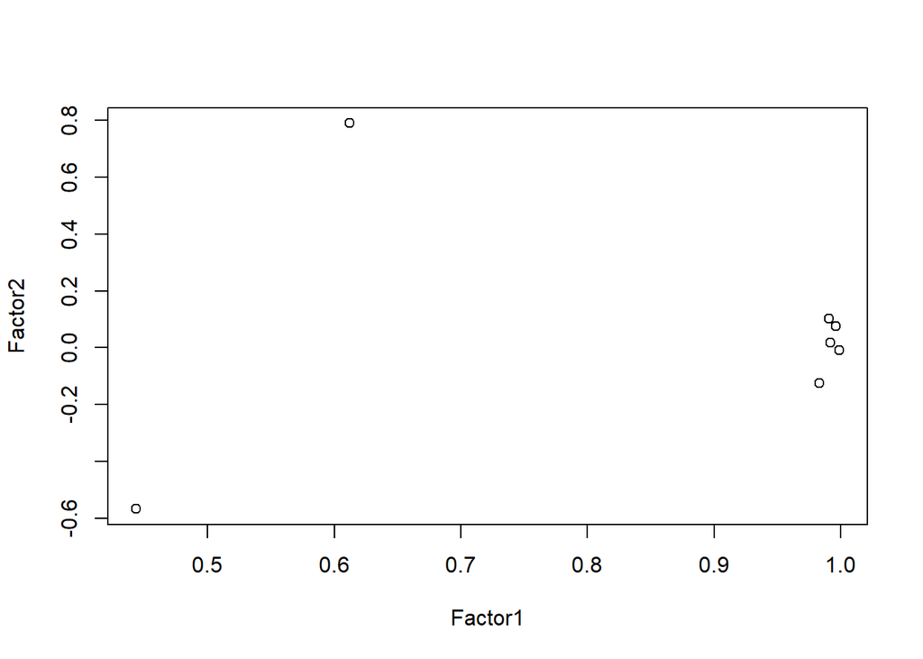

```r
plot(rfa$loadings)
```

**4.6 Path Analysis**

Relationships described in the following figure in expected to exist among the variables in `longley` dataset.

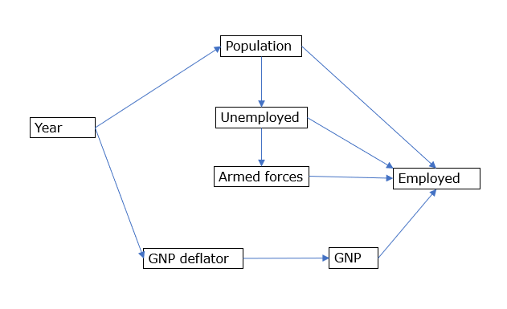

```r
shp.model <- 'Employed~Population+Unemployed+Armed.Forces+GNP
GNP~GNP.deflator
GNP.deflator~Year
Population~Year
Unemployed~Population
Armed.Forces~Unemployed'
library(lavaan)
shp.fit <- sem(shp.model, data=longley)
summary(shp.fit, standardized=TRUE, rsquare=TRUE, fit.measures=TRUE)
```

```
## lavaan 0.6-9 ended normally after 109 iterations
##
##   Estimator                                         ML
##   Optimization method                           NLMINB
##   Number of model parameters                        15
##
##   Number of observations                            16
##
## Model Test User Model:
##
##   Test statistic                                92.612
##   Degrees of freedom                                12
##   P-value (Chi-square)                           0.000
##
## Model Test Baseline Model:
##
##   Test statistic                               373.800
##   Degrees of freedom                                21
##   P-value                                        0.000
##
## User Model versus Baseline Model:
##
##   Comparative Fit Index (CFI)                    0.772
##   Tucker-Lewis Index (TLI)                       0.600
##
## Loglikelihood and Information Criteria:
##
##   Loglikelihood user model (H0)               -295.785
##   Loglikelihood unrestricted model (H1)       -249.479
##
##   Akaike (AIC)                                 621.571
##   Bayesian (BIC)                               633.160
##   Sample-size adjusted Bayesian (BIC)          587.256
##
## Root Mean Square Error of Approximation:
##
##   RMSEA                                          0.648
##   90 Percent confidence interval - lower         0.529
##   90 Percent confidence interval - upper         0.774
##   P-value RMSEA <= 0.05                          0.000
```

[output cut: 31 more lines]

```
##    .Employed          0.148    0.052    2.828    0.005    0.148    0.011
##    .GNP             155.145   54.852    2.828    0.005  155.145    0.017
##    .GNP.deflator      1.924    0.680    2.828    0.005    1.924    0.018
##    .Population        0.547    0.193    2.828    0.005    0.547    0.012
##    .Unemployed     4327.760 1530.094    2.828    0.005 4327.760    0.529
##    .Armed.Forces   4397.440 1554.730    2.828    0.005 4397.440    0.969
##
## R-Square:
##                    Estimate
##     Employed          0.989
##     GNP               0.983
##     GNP.deflator      0.982
##     Population        0.988
##     Unemployed        0.471
##     Armed.Forces      0.031
```

Comparative Fit Index (CFI) is 0.772

Akaike (AIC) is 621.571

RMSEA is 0.648

Modification indices of the model are investigated for further improve the model.

```r
modificationindices(shp.fit)
```

```
##             lhs op          rhs     mi       epc   sepc.lv sepc.all sepc.nox
## 16         Year ~~         Year  0.000     0.000     0.000    0.000    0.000
## 17     Employed ~~          GNP  0.150     0.583     0.583    0.122    0.122
## 18     Employed ~~ GNP.deflator  2.279    -0.255    -0.255   -0.479   -0.479
## 19     Employed ~~   Population  1.568    -0.104    -0.104   -0.365   -0.365
## 22          GNP ~~ GNP.deflator  8.415   -12.642   -12.642   -0.732   -0.732
## 23          GNP ~~   Population  4.791     5.041     5.041    0.547    0.547
## 24          GNP ~~   Unemployed  1.129  -217.645  -217.645   -0.266   -0.266
## 25          GNP ~~ Armed.Forces  0.265  -106.202  -106.202   -0.129   -0.129
## 26 GNP.deflator ~~   Population  2.704    -0.422    -0.422   -0.411   -0.411
## 27 GNP.deflator ~~   Unemployed  2.427   -35.542   -35.542   -0.389   -0.389
## 28 GNP.deflator ~~ Armed.Forces  1.798    30.832    30.832    0.335    0.335
## 29   Population ~~   Unemployed  0.502     8.671     8.671    0.178    0.178
## 30   Population ~~ Armed.Forces  2.959   -21.152   -21.152   -0.431   -0.431
## 31   Unemployed ~~ Armed.Forces  7.388 -4317.751 -4317.751   -0.990   -0.990
```

[output cut: 33 more lines]

Two new paths, GNP~Population and Armed.Forces~GNP.deflation are added to the model as suggested by the high modification indices.

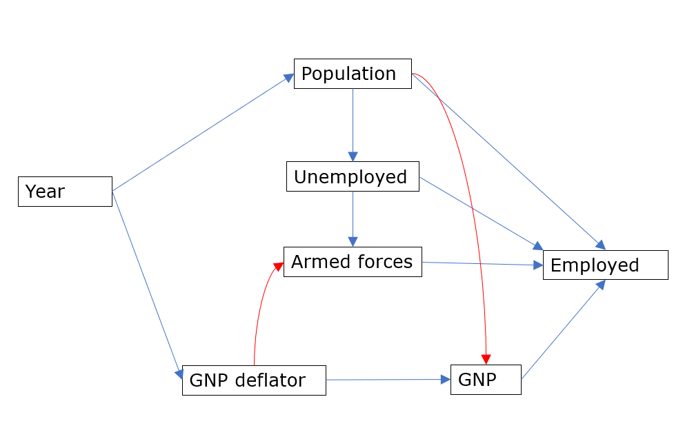

Modified model

```r
shp.model <- 'Employed~Population+Unemployed+Armed.Forces+GNP
GNP~GNP.deflator+Population
GNP.deflator~Year
Population~Year
Unemployed~Population
Armed.Forces~Unemployed+GNP.deflator'
library(lavaan)
shp.fit <- sem(shp.model, data=longley)
summary(shp.fit, standardized=TRUE, rsquare=TRUE, fit.measures=TRUE)
```

```
## lavaan 0.6-9 ended normally after 146 iterations
##
##   Estimator                                         ML
##   Optimization method                           NLMINB
##   Number of model parameters                        17
##
##   Number of observations                            16
##
## Model Test User Model:
##
##   Test statistic                                65.452
##   Degrees of freedom                                10
##   P-value (Chi-square)                           0.000
##
## Model Test Baseline Model:
##
##   Test statistic                               373.800
##   Degrees of freedom                                21
##   P-value                                        0.000
##
## User Model versus Baseline Model:
##
##   Comparative Fit Index (CFI)                    0.843
##   Tucker-Lewis Index (TLI)                       0.670
##
## Loglikelihood and Information Criteria:
##
##   Loglikelihood user model (H0)               -282.205
##   Loglikelihood unrestricted model (H1)       -249.479
##
##   Akaike (AIC)                                 598.411
##   Bayesian (BIC)                               611.545
##   Sample-size adjusted Bayesian (BIC)          559.520
##
## Root Mean Square Error of Approximation:
##
##   RMSEA                                          0.589
##   90 Percent confidence interval - lower         0.458
##   90 Percent confidence interval - upper         0.728
##   P-value RMSEA <= 0.05                          0.000
```

[output cut: 33 more lines]

```
##    .Employed          0.148    0.052    2.828    0.005    0.148    0.013
##    .GNP              63.846   22.573    2.828    0.005   63.846    0.007
##    .GNP.deflator      1.924    0.680    2.828    0.005    1.924    0.018
##    .Population        0.547    0.193    2.828    0.005    0.547    0.012
##    .Unemployed     4327.749 1530.090    2.828    0.005 4327.749    0.529
##    .Armed.Forces   1957.004  691.905    2.828    0.005 1957.004    0.468
##
## R-Square:
##                    Estimate
##     Employed          0.987
##     GNP               0.993
##     GNP.deflator      0.982
##     Population        0.988
##     Unemployed        0.471
##     Armed.Forces      0.532
```

Comparative Fit Index (CFI) is 0.843

Akaike (AIC) is 598.411

RMSEA is 0.589

Shown by the increased fit and reduced AIC and RMSEA, the model has been improved by the modifications.

============================================================

Github repository https://github.com/VajiraL/UT_EnvSys21